# Calculating PGS for WCHS

Peter Fiorica

2023-10-17

# Introduction and Background

### Code

This document is intended to cover an overview and background of calculating 6 different PGS for WCHS individuals. I will be basing my code off of Haiyang Sheng’s code for calculating PGS in CCR. I am using the directory for guidance `/projects/rpci/songyao/Haiyang/PGS/SBP.Diabetes.2PGS_08122023`.

### Directories

My working directory will be based in `/projects/rpci/wchs/pnfioric/pgs_wchs/`

### PGS

We will be calculating the PGS from the following files:

```
AABCG_PRS_Black.xlsx
ROR-p_PGS_Shieh_et_al_2023.xlsx
SupplementalTable_S5_coef_ERpos_ddac102.csv
PRS313_PGS000004_hmPOS_GRCh37.txt
SupplementalTable_S4_coef_overall_hybrid_ddac102.csv
SupplementalTable_S6_coef_ERneg_ddac102.csv
```

`AABCG_PRS_Black.xlsx` GRCh38

`ROR-p_PGS_Shieh_et_al_2023.xlsx` GRCh37

`PRS313_PGS000004_hmPOS_GRCh37.txt` GRCh37

`SupplementalTable_S4_coef_overall_hybrid_ddac102.csv` GRCh38

`SupplementalTable_S5_coef_ERpos_ddac102.csv` GRCh38

`SupplementalTable_S6_coef_ERneg_ddac102.csv` GRCh38

**The Gao files are all labeled hg38, but they are 37.**

### Genotypes

We will be using WCHS genotypes for 6692 (500 AABC + 3961 AMBER + 2231 WCHS) individuals. These genotypes are in hg38 build. They were filtered using the NHBLI TOPMed Consortium reference panel. SNPs were filtered to keep snps with $R^{2}>0.3$ and MAF>0.01. After merging these, groups above genotypes, SNPs were kept with a genotype call rate >98%.

Apparently, these genotypes include duplicates. I am not going to run the IBD pruning to remove them, but I am going to identify the duplicate IDs.

```r
ID_key <- read_xlsx("C://Users/pe42518/OneDrive - University at Buffalo/Documents/Ambrosone_Yao/Pathways_GWAS_TILs/AABCGS_WCHS_IDs.xlsx")

genotype_ids_full<-fread("C://Users/pe42518/Downloads/wchs_geno002_full.fam", header = F)

duplicates_to_remove <- c("NJ03536", "WC00537", "NJ09014", "NJ09141")
geno_to_remove <- c("A006788", "A018806" , "A038363",  "A038456")
#These are four genetic duplicates I identified from IBD pruning. See IBD_wchs_check.Rmd for more details. Karen Hulme and Rochelle Payne Ondracek identified that they were genotyped twice because they were initially enrolled as controls and later cases.
ID_key <- ID_key %>% filter(!WCHS_ID %in% duplicates_to_remove)

genotype_ids<- genotype_ids_full %>%
  mutate(V1=sub("_.*$", "", V1))

genotype_ids_w_AABCGS_ID <- genotype_ids %>% filter(V1 %in% ID_key$AABCGS_ID)
genotype_ids_wo_AABCGS_ID <- genotype_ids %>% filter(!V1 %in% ID_key$AABCGS_ID)

remaining_IDs<-ID_key %>% filter(!AABCGS_ID %in% genotype_ids_w_AABCGS_ID$V1)

wchs_genotype_ids<-fread("C://Users/pe42518/Downloads/wchs_geno002_full.fam", header = F) %>%
  mutate(V1=sub("^[^_]*_WCHS_", "", V1))

table(remaining_IDs$AABCGS_ID %in% wchs_genotype_ids$V1)
```

```
##
## FALSE
##    44
```

```r
table(remaining_IDs$OriID %in% wchs_genotype_ids$V1)
```

```
##
## FALSE
##    44
```

```r
table(remaining_IDs$AABC_ID %in% wchs_genotype_ids$V1)
```

```
##
## FALSE
##    44
```

```r
table(remaining_IDs$WCHS_ID %in% wchs_genotype_ids$V1)
```

```
##
## FALSE
##    44
```

```r
table(remaining_IDs$AABCGS_ID %in% genotype_ids$V1)
```

```
##
## FALSE
##    44
```

```r
table(remaining_IDs$OriID %in% genotype_ids$V1)
```

```
##
## FALSE
##    44
```

```r
table(remaining_IDs$AABC_ID %in% genotype_ids$V1)
```

```
##
## FALSE
##    44
```

```r
table(remaining_IDs$WCHS_ID %in% genotype_ids$V1)
```

```
##
## FALSE
##    44
```

```r
updated_fam<- genotype_ids_full %>% filter(V2 %in% genotype_ids_w_AABCGS_ID$V2)
fwrite(updated_fam, "C://Users/pe42518/OneDrive - University at Buffalo/Documents/Ambrosone_Yao/Pathways_GWAS_TILs/3044_updated_genotypes_wchs.fam", col.names = F, row.names = F, sep = " ", quote = F)

missing_fam<- genotype_ids_full %>% filter(!V2 %in% genotype_ids_w_AABCGS_ID$V2)
fwrite(missing_fam, "C://Users/pe42518/OneDrive - University at Buffalo/Documents/Ambrosone_Yao/Pathways_GWAS_TILs/3648_missing_IDs_genotypes_wchs.fam", col.names = F, row.names = F, sep = " ", quote = F)

fwrite(remaining_IDs, "C://Users/pe42518/OneDrive - University at Buffalo/Documents/Ambrosone_Yao/Pathways_GWAS_TILs/IDs_wo_genotypes.txt", col.names = T, row.names = F, sep = " ", quote = F)
```

# Understanding Haiyang’s Code

`UKB.PGS_HS.R`

1. Sets up an environment to read in PGS
2. Reads in PGS weights from PGS Catalog files where the column names are rsID, Chr, position, effect allele, other allele, effect weight
3. Creates a folder for each PGS.
   1. Within each folder, he makes subdirectories for ethnicity that contain 3 files per chromosome: calculated score, number of missing/unmatched PGS variants, number of matched PGS variants.
4. Reads in each genotype by population, chromosome, and subchromosome file.
5. Matches SNPs from genotype to weights
6. Reports missing or present variants from SNPs and weights
7. Calculates PGS
8. Writes PGS file and log for each individual.

# Cleaning PGS Files

```r
pgs.dir<-"C://Users/pe42518/OneDrive - University at Buffalo/Documents/Ambrosone_Yao/WCHS_PGS_Analysis/BrCa_PRS/"
#HG37
#These files need to have their SNP positions lifted over. We will generated a BED file to uploaded the UCSC online liftover tool.
#https://genome.ucsc.edu/cgi-bin/hgLiftOver

Shieh <- read_xlsx(pgs.dir %&%"ROR-P PGS_Shieh et al 2023.xlsx") %>%
  mutate(bed_chr= paste("chr", chr, sep = "")) %>%
  mutate(bed_pos1 = position) %>%
  mutate(bed_pos2 = as.numeric(position)+1)

shieh_bed<-Shieh %>% select(starts_with("bed_"))

PGS000004<- fread(pgs.dir %&% "PRS313_PGS000004_hmPOS_GRCh37.txt", header = T) %>%
  mutate(bed_chr= paste("chr", chr_name, sep = "")) %>%
  mutate(bed_pos1 = chr_position) %>%
  mutate(bed_pos2 = as.numeric(chr_position)+1)

PGS000004_bed<-PGS000004 %>% select(starts_with("bed_"))

fwrite(shieh_bed, pgs.dir %&%"shieh_bed.bed", col.names = F, row.names =F, sep = "\t", quote = F)
fwrite(PGS000004_bed, pgs.dir %&%"PGS000004_bed.bed", col.names = F, row.names =F, sep = "\t", quote = F)
```

For both files, all SNPs were successfully lifted over. Now we can update the PGS.

```r
PGS000004_hg38_bed<-fread(pgs.dir %&% "PGS000004_hglft_genome_1afde_188450.bed", header = F) #%>%
  #separate(V4, into = c("chr_38", "pos_38"), sep = ":") %>%
  #separate(pos_38, into = c("pos1","pos2"), sep = "-")
shieh_hg38_bed <- fread(pgs.dir %&% "Shieh_hglft_genome_1a6bd_187fa0.bed", header = F)#%>%
  #separate(V4, into = c("chr_38", "pos_38"), sep = ":") %>%
  #separate(pos_38, into = c("pos1","pos2"), sep = "-")

shieh_full<- bind_cols(Shieh, shieh_hg38_bed)
PGS000004_full<-bind_cols(PGS000004, PGS000004_hg38_bed)

shieh_weights <- shieh_full %>%
  select(effect_allele=risk, reference_allele=other, effect_weight=Coefficient, chr_name = chr , chr_pos=V2)
PGS000004_weights <- PGS000004_full %>%
  select(effect_allele=effect_allele, reference_allele=other_allele, effect_weight=effect_weight, chr_name , chr_pos=V2)

fwrite(shieh_weights, pgs.dir %&% "PGSShieh2023.txt", col.names = T, sep = " ", quote = F, row.names = F)
fwrite(PGS000004_weights, pgs.dir %&% "PGS000004.txt", col.names = T, sep = " ", quote = F, row.names = F)
```

```r
## Gao 2022
## ER POS
gao_erpos<- fread(pgs.dir %&%"SupplementalTable_S5_coef_ERpos_ddac102.csv", header = T) %>%
  mutate(bed_chr= paste("chr", Chromosome, sep = "")) %>%
  mutate(bed_pos1 = `Position, hg38`) %>%
  mutate(bed_pos2 = as.numeric(`Position, hg38`)+1)

gao_erpos_bed<-gao_erpos %>% select(starts_with("bed_"))
fwrite(gao_erpos_bed, pgs.dir %&% "gao_erpos_bed.bed", col.names = F, sep = "\t", quote = F, row.names = F)

## Overall Breast Cancer
gao_brca<- fread(pgs.dir %&% "SupplementalTable_S4_coef_overall_hybrid_ddac102.csv", header = T) %>%
  mutate(bed_chr= paste("chr", Chromosome, sep = "")) %>%
  mutate(bed_pos1 = `Position, hg38`) %>%
  mutate(bed_pos2 = as.numeric(`Position, hg38`)+1)

gao_brca_bed<-gao_brca %>% select(starts_with("bed_"))
fwrite(gao_brca_bed, pgs.dir %&% "gao_brca_bed.bed", col.names = F, sep = "\t", quote = F, row.names = F)


## ER NEG
gao_erneg<-fread(pgs.dir %&% "SupplementalTable_S6_coef_ERneg_ddac102.csv", header = T)%>%
  mutate(bed_chr= paste("chr", Chromosome, sep = "")) %>%
  mutate(bed_pos1 = `Position, hg38`) %>%
  mutate(bed_pos2 = as.numeric(`Position, hg38`)+1)

gao_erneg_bed<-gao_erneg %>% select(starts_with("bed_"))
fwrite(gao_erneg_bed, pgs.dir %&% "gao_erneg_bed.bed", col.names = F, sep = "\t", quote = F, row.names = F)
```

```r
#ER POSITIVE
gao_erpos_hg38_bed<-fread(pgs.dir %&% "gao_erpos_hglft_genome_3d40a_c0b440.bed", header = F)%>%
  separate(V4, into = c("chr_37", "pos_37"), sep = ":") %>%
  separate(pos_37, into = c("pos1","pos2"), sep = "-") %>%
  mutate(pos1=as.numeric(pos1))

gao_erpos_full <-left_join(gao_erpos, gao_erpos_hg38_bed, by = c("bed_chr"="V1", "bed_pos2" = "pos1")) %>%
  mutate(V2= if_else(is.na(V2)==TRUE, `Position, hg38`, V2 ))
gao_erpos_full <- gao_erpos_full %>%  filter(!duplicated(gao_erpos_full))


gao_erpos_weight <- gao_erpos_full %>%
  select(effect_allele= `ALT allele`, reference_allele = `REF allele`, effect_weight=`Coef.`, chr_name=Chromosome , chr_pos=V2)


#OVERAL BREAST CANCER
gao_brca_hg38_bed<-fread(pgs.dir %&% "gao_brca_hglft_genome_23ab2_c11ca0.bed", header = F)%>%
  separate(V4, into = c("chr_37", "pos_37"), sep = ":") %>%
  separate(pos_37, into = c("pos1","pos2"), sep = "-") %>%
  mutate(pos1=as.numeric(pos1))

gao_brca_full <-left_join(gao_brca, gao_brca_hg38_bed, by = c("bed_chr"="V1", "bed_pos2" = "pos1")) %>%
  mutate(V2= if_else(is.na(V2)==TRUE, `Position, hg38`, V2 ))
gao_brca_full <- gao_brca_full %>%  filter(!duplicated(gao_brca_full))

gao_brca_weights<- gao_brca_full %>%
  select(effect_allele= `ALT allele`, reference_allele = `REF allele`, effect_weight=`Coef for overall cancer`, chr_name=Chromosome , chr_pos=V2)

#ER NEGATIVE
gao_erneg_hg38_bed<-fread(pgs.dir %&% "gao_erneg_hglft_genome_24d43_c121b0.bed", header = F)%>%
  separate(V4, into = c("chr_37", "pos_37"), sep = ":") %>%
  separate(pos_37, into = c("pos1","pos2"), sep = "-") %>%
  mutate(pos1=as.numeric(pos1))

gao_erneg_full <-left_join(gao_erneg, gao_erneg_hg38_bed, by = c("bed_chr"="V1", "bed_pos2" = "pos1")) %>%
  mutate(V2= if_else(is.na(V2)==TRUE, `Position, hg38`, V2 ))

gao_erneg_full <- gao_erneg_full %>%  filter(!duplicated(gao_erneg_full))

gao_erneg_weight<-gao_erneg_full %>%
  select(effect_allele = `ALT allele`, reference_allele = `REF allele`, effect_weight=`Coef.`, chr_name=Chromosome , chr_pos=V2)


#WRITE FILES
fwrite(gao_brca_weights, pgs.dir %&% "PGSGao2022_BrCa.txt", col.names = T, sep = " ", quote = F, row.names = F )
fwrite(gao_erpos_weight, pgs.dir %&% "PGSGao2022_ERPOS.txt", col.names = T, sep = " ", quote = F, row.names = F )
fwrite(gao_erneg_weight, pgs.dir %&% "PGSGao2022_ERNEG.txt", col.names = T, sep = " ", quote = F, row.names = F )
```

# HG38

```r
#AABCGS
AABCGS_black<- read_xlsx(pgs.dir %&% "AABCG_PRS_Black.xlsx") %>%
  separate(Allelesa, into = c("effect_allele", "reference_allele"), sep = "/") %>%
  filter(!is.na(effect_allele))

AABCGS_black_weights <- AABCGS_black %>%
  select(effect_allele, reference_allele, effect_weight=OVR_BETA, chr_name=Chr , chr_pos=bd38)

fwrite(AABCGS_black_weights, pgs.dir %&% "PGSAABCGS_black.txt", col.names = T, sep = " ", quote = F, row.names = F )
```

# Cleaning Genotype Files

Haiyang’s code uses genotype files that are in GDS format. I have never used this format before, but it looks like plink files can be converted to it with `snpgdsBED2GDS()` from the `SNPRelate` package in R. First, I am going to try this out with chromosome 22 to see if it will work. To do this, I am going to launch an interactive session on CCR and go forward with the following steps:

```
salloc --reservation=ubhpc-future --qos=general-compute --partition=general-compute  --job-name "MyJob" --nodes=1 --ntasks=1 --mem=16G --time=04:30:00
srun --pty /bin/bash --login

module load plink

pwd
#/projects/rpci/wchs/pnfioric/geno_filter_WCHS_Merged_0.01_0.3_AABC_AMBER_FULL/

plink --bfile /projects/rpci/wchs/pnfioric/geno_filter_WCHS_Merged_0.01_0.3_AABC_AMBER_FULL/wchs_geno002_full --chr 22 --keep /projects/rpci/wchs/pnfioric/pgs_wchs/3048_updated_genotypes_wchs.fam --make-bed --out /projects/rpci/wchs/pnfioric/geno_filter_WCHS_Merged_0.01_0.3_AABC_AMBER_FULL/wchs_3048_chr22
```

This quickly generated the chr 22 bfiles we need. From here, we will convert the to GDS. Initially, I ran `plink2gds.R` to convert plink to GDS files, but it turns out some of the chromosome files are too large to be read into R. Haiyang’s code originally used 10 subchromosome files, so that is what we will do. To split these files into groups of 10, we run `split_subchromosome.py`. After dividing the chromosome files into even smaller chunks, we will then convert them to `.gds` files. We do this with the `plink2gds.R` script.

# Calculating PGS.

To calculate PGS, I ran `call_pgs_calc.sh` which calls `UKB.PGS_PNF1.R`. This R script requires an integer to specify which PGS from a folder of PGS’s is going to be calculated. Since we only had six PGS, I specified the integers manually.

After this, I ran `merge_PNF.R`. This combines the PGS for each individual across all of their chromosomes. It also removes the 4 duplicate individuals that were identified in the process of calculating PGS. Lastly, I ran `merge.valid.nvar_PNF.R`, which provides summary information for the PGS calculated.

```r
PGS_total<-fread(pgs.dir %&% "WCHS_BrCa_6_PGS.xlsx.csv", header = T)
summary(PGS_total$PGS_Breast_Cancer_313)
```

```
##    Min. 1st Qu.  Median    Mean 3rd Qu.    Max.
## -2.3472 -0.9639 -0.6210 -0.6147 -0.2792  1.0866
```

```r
summary(PGS_total$PGS_AABCGS_black)
```

```
##    Min. 1st Qu.  Median    Mean 3rd Qu.    Max.
##   5.147   6.467   6.707   6.704   6.948   7.955
```

```r
summary(PGS_total$PGS_Gao2022_BrCa)
```

```
##    Min. 1st Qu.  Median    Mean 3rd Qu.    Max.
##   1.046   2.470   2.777   2.754   3.062   4.267
```

```r
summary(PGS_total$PGS_Gao2022_ERNEG)
```

```
##    Min. 1st Qu.  Median    Mean 3rd Qu.    Max.
## -0.7217  1.3775  1.6332  1.5878  1.8884  3.0495
```

```r
summary(PGS_total$PGS_Gao2022_ERPOS)
```

```
##    Min. 1st Qu.  Median    Mean 3rd Qu.    Max.
##   1.248   3.160   3.519   3.469   3.857   5.246
```

```r
summary(PGS_total$PGS_Shieh2023)
```

```
##    Min. 1st Qu.  Median    Mean 3rd Qu.    Max.
##  -47.69  -36.21  -32.75  -32.61  -29.06  -14.98
```

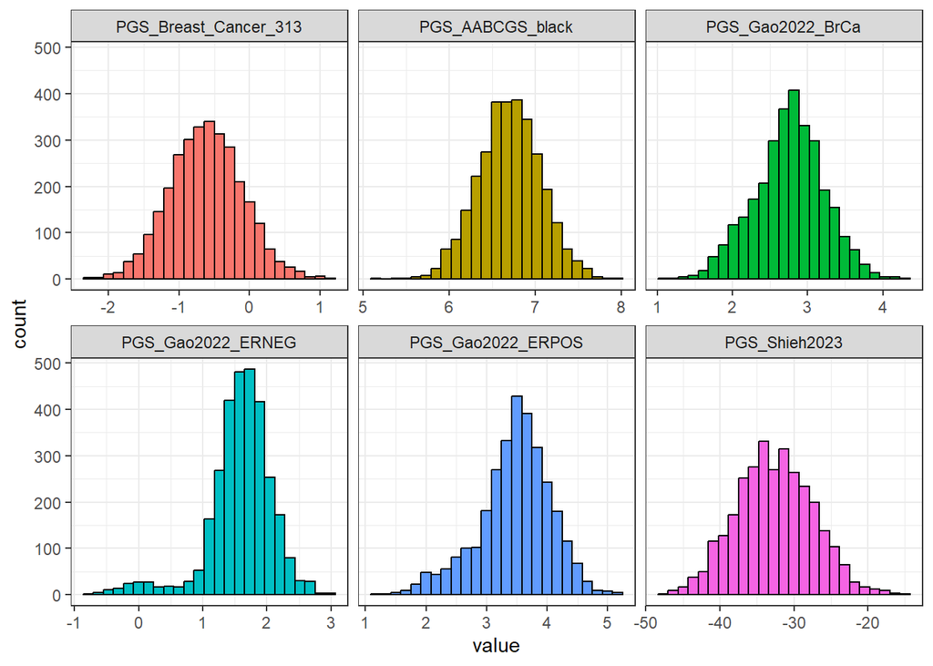

```r
# Gather data into long format
data_long <- melt(PGS_total, id.vars = "samples", variable.name = "PGS")
# Filter for columns starting with "PGS_"
data_long <- data_long[grepl("^PGS_", PGS)]

# Create histograms
ggplot(data_long, aes(value, fill= PGS)) +
    geom_histogram(bins = 25, color = "black") +
    facet_wrap(~PGS, scales = 'free_x') + theme_bw() + guides(fill="none")
```

## Adding WCHS IDs to Genotype labels on PGS

```r
ID_key <- read_xlsx("C://Users/pe42518/OneDrive - University at Buffalo/Documents/Ambrosone_Yao/Pathways_GWAS_TILs/AABCGS_WCHS_IDs.xlsx")

PGS_total<-fread(pgs.dir %&% "WCHS_BrCa_6_PGS.xlsx.csv", header = T) %>%
  mutate(Abridged_Genotype_ID=sub("_.*$", "", samples))

PGS_matched<-left_join(PGS_total,ID_key,  by = c("Abridged_Genotype_ID"="AABCGS_ID")) %>%
  select(Genotype_ID=samples, WCHS_ID, AABC_ID, Abridged_Genotype_ID_AABCGS_ID= Abridged_Genotype_ID, PGS_Breast_Cancer_313, PGS_AABCGS_black,    PGS_Gao2022_BrCa, PGS_Gao2022_ERNEG, PGS_Gao2022_ERPOS, PGS_Shieh2023)
fwrite(PGS_matched, pgs.dir %&% "WCHS_BrCa_6_PGS_with_WCHS_IDs.csv", col.names = T, row.names = F, sep= ",", quote = F)
```